# CITS3007 lab 1 – Development environment – solutions

**Laptop requirement**

When attending lab classes, you will need access to a laptop, as this unit makes use of software which is not permitted to be installed on UWA lab machines.

Any one of a Windows, Linux or Mac OS laptop are acceptable. They will need enough disk space and RAM to run Oracle [VirtualBox](https://www.virtualbox.org) and a virtual machine instance – 15 spare GB of disk space and 4 GB of RAM would be about the minimum needed.

## 1. Setting up the C development environment

To complete the lab work for this unit, you will use a standardised C development environment – the one we use is based on Ubuntu 20.04.

To access the environment, there are two options:

- Install two open source tools ([VirtualBox](https://www.virtualbox.org) and [Vagrant](https://www.vagrantup.com)) on your laptop or home PC. See VirtualBox and Vagrant, below.

Or alternatively:

- Access the development environment on the Web using [GitPod](https://gitpod.io/) (which provides web-based access to development environments hosted in the cloud). See Using GitPod, below.

For the first couple of labs, **either of these options** will be fine; but for some of the later labs, you *will* need to use **VirtualBox+Vagrant**, so you should install them now and ensure you can get them working.

**VirtualBox for ARM64 (M-series) Macs**

VirtualBox *is* available for recent Mac models.

On July 19th a newer version of VirtualBox was released which hasn’t yet been ported to the ARM64 architecture – but you *can* still use the older version, VirtualBox 7.0.8.

Visit https://www.virtualbox.org/wiki/Download_Old_Builds_7_0 to see the older versions of VirtualBox, and download the one labelled “Developer preview for macOS / Arm64 (M1/M2) hosts”.

### VirtualBox and Vagrant

To install VirtualBox and Vagrant:

1. Visit https://www.virtualbox.org/wiki/Downloads, download the appropriate VirtualBox package for your platform (Windows, MacOS or Linux), and install it.
   - On Windows, the installer is an `.exe` file you can simply run by double-clicking.
   - On MacOS, the installer is a `.dmg` file – double click on it for instructions.
   - On Ubuntu distributions a `.deb` file is provided – we assume you already know how to install one of these. If you are using a non-Ubuntu distribution, consult the VirtualBox documentation for instructions on how to install.
2. Visit https://www.vagrantup.com/downloads, download the appropriate Vagrant package for your platform, and install it.
   - On Windows, the installer is an `.msi` file you can run by double-clicking.
   - On MacOS, you can either download a `.dmg` file, or (if you have [Homebrew](https://brew.sh) installed) there are instructions for adding Vagrant with a `brew install` command.
   - On Ubuntu, it’s recommended you install Vagrant using the APT package manager (see “Package manager for Linux” on the Vagrant page).
3. Check that Vagrant has been successfully installed.

   On Windows, open a “Command Prompt” window. On MacOS or Linux, open a terminal window.

   Then type `vagrant --version`; Vagrant should display

   ```
   Vagrant 2.2.19
   ```

4. Test a small virtual machine (VM) image. Create a new directory (called e.g. `vagrant-test`), open a terminal window and `cd` into the directory.

   Type `vagrant init generic/alpine316`, then `vagrant up --provider=virtualbox`. Vagrant should take about a minute to download a virtual machine containing [Alpine Linux](https://www.alpinelinux.org) and configure it for use.

   If you type `vagrant ssh`, Vagrant will connect to the new virtual machine using [`ssh`](https://www.ssh.com/academy/ssh) and present you with a shell prompt:

   ```
   $ vagrant ssh
   alpine316:~$
   ```

   If this works, you can simply exit the shell by typing `exit` or hitting `ctrl-D`. If it doesn’t, please see one of the lab facilitators for assistance.

   (Note that on Linux, if you already have `libvirt` installed: `libvirt` and VirtualBox can’t both run at the same time. Ensure that `libvirt` isn’t running by typing `sudo systemctl stop libvirtd`.)
5. Download a VM containing the standard CITS3007 development environment. Note that this will likely take **around 5–10 minutes**, so once you’ve started the process, move onto the next exercise.

   Create a new directory (called e.g. `cits3007-test`), open a terminal window and `cd` into the directory.

   Type `vagrant init arranstewart/cits3007-ubuntu2004`, then `vagrant up --provider=virtualbox`. Vagrant should take around 5–10 minutes to download a virtual machine and configure it for use. The output from Vagrant should look something like the following:

   ```
   Bringing machine 'default' up with 'virtualbox' provider...
   ==> default: Importing base box 'arranstewart/cits3007-ubuntu2004'...
   ==> default: Matching MAC address for NAT networking...
   ==> default: Checking if box 'arranstewart/cits3007-ubuntu2004' version '0.1.2' is up to date...
   ==> default: Setting the name of the VM: xxx-cits3007-test_1658816964468_16898
   ==> default: Clearing any previously set forwarded ports...
   ==> default: Fixed port collision for 22 => 2222. Now on port 2200.
   ==> default: Clearing any previously set network interfaces...
   ==> default: Preparing network interfaces based on configuration...
       default: Adapter 1: nat
   ==> default: Forwarding ports...
       default: 22 (guest) => 2200 (host) (adapter 1)
   ==> default: Booting VM...
   ==> default: Waiting for machine to boot. This may take a few minutes...
       default: SSH address: 127.0.0.1:2200
       default: SSH username: vagrant
       default: SSH auth method: private key
       default: Warning: Connection reset. Retrying...
       default: Warning: Remote connection disconnect. Retrying...
       default: Warning: Connection reset. Retrying...
       default:
       default: Vagrant insecure key detected. Vagrant will automatically replace
       default: this with a newly generated keypair for better security.
       default:
       default: Inserting generated public key within guest...
       default: Removing insecure key from the guest if it's present...
       default: Key inserted! Disconnecting and reconnecting using new SSH key...
   ==> default: Machine booted and ready!
   ==> default: Checking for guest additions in VM...
   ==> default: Setting hostname...
   ```

   Once it’s done, you can type `vagrant ssh` to get shell access to the new VM:

   ```
   $ vagrant ssh
   vagrant@cits3007-ubuntu2004:~$
   ```

6. Optional: install VS Code and the “Remote-SSH” extension.

   The standard CITS3007 development environment VM comes with the `vim` editor already installed, but many people find it more comfortable developing and debugging code using a graphical editor.

   [Visual Studio Code](https://code.visualstudio.com) (VS Code) works well on Windows, Mac and Linux computers, and allows you to seamlessly write and debug code on a Vagrant VM.

   Once you’ve got a CITS3007 development environment VM running (see the last step), install VS Code by downloading it from https://code.visualstudio.com.

   Start VS Code (on Linux or MacOS, the command to do so from the terminal is just `code`), and from the menu select ‘File’ / ‘Preferences’ / ‘Extensions’. In the search box at the top left of the window, type `remote ssh` and hit enter. The top hit should be the “Remote - SSH” extension; select it, then click the “install” button.

[figure not shown]

   In the lower left corner of the window you should see a button with facing angle bracket symbols (“><”) – click on it:

[figure not shown]

   VS Code will then offer several options – select “Open SSH configuration file”.

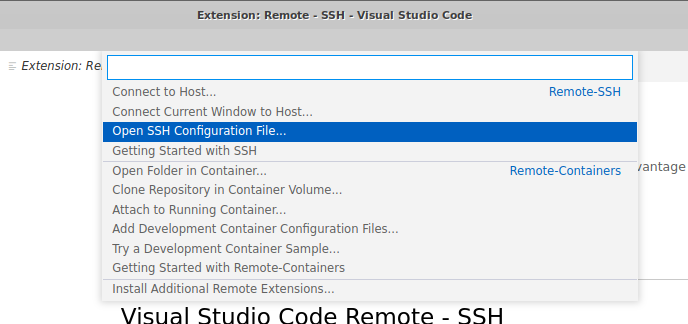

   Select the first configuration file VS Code suggests and open it.

   Now, in the terminal window from which you started the Vagrant VM, type `vagrant ssh-config`.

   Vagrant will output configuration settings which can be used with `ssh` – something like the following:

   ```
   Host default
     HostName 127.0.0.1
     User vagrant
     Port 2200
     UserKnownHostsFile /dev/null
     StrictHostKeyChecking no
     PasswordAuthentication no
     IdentityFile /home/smithj/cits3007-test/.vagrant/machines/default/virtualbox/private_key
     IdentitiesOnly yes
     LogLevel FATAL
   ```

   Paste this `ssh` configuration into the file which is open in VS Code, and save it. You may want to change the first line from `Host default` to something more informative, like `Host cits3007-test`.

   Pasting this configuration informs VS Code about the new VM and how to connect to it. If you again click on the “remote window” button in the lower left corner of VS Code, one of the options is “Connect to Host”, and if you select *that*, one of the options should be the new VM you specified (e.g. `cits3007-test`).

   VS Code will open a new window (and spend a few seconds setting up some software on the VM): in this window, you can use VS Code as normal, but all files you can access will be on the virtual machine.

#### Vagrant cheat sheet

You can find a useful “cheat sheet” of commands for managing Vagrant VMs here: https://cheatography.com/davbfr/cheat-sheets/vagrant-cheat-sheet/.

### Using GitPod

If you don’t yet have access to a laptop on which you can install VirtualBox and Vagrant, then for the first couple of labs you can also use a cloud-based development VM provided by [GitPod](https://gitpod.io/).

You’ll need to have a GitHub account for this, so if you don’t have one already, visit https://github.com/ and create one.

Once that’s done, paste the following URL into your browser:

https://gitpod.io/#https://github.com/cits3007/ubuntu-gitpod

You’ll be prompted to use GitHub to access GitPod:

[figure not shown]

Click “Continue with GitHub”.

GitPod will start a cloud-based virtual machine in which the standard CITS3007 environment is available, and the latest version of [Visual Studio Code](https://code.visualstudio.com) (VS Code) editor is running:

[figure not shown]

Initially, VS Code will start with the folder `/workspace/ubuntu-gitpod` open, which contains code downloaded from https://github.com/cits3007/ubuntu-gitpod. However, you can easily create and open new folders if desired.

## 2. Concept review questions

If possible, it’s recommended you work on this section in pairs or small groups and compare answers.

### 2.1. Definitions

For each of the following concepts, review the definition given in the lecture slides, and explain it in your own words. If you can, give an example, based on your own experience or from recent news reports:

1. threat
2. vulnerability
3. confidentiality
4. integrity
5. availability

**Sample solutions**

Definitions for all these terms are in the week 1 lecture slides: your explanations should be in your own words.

*Examples* of each could be:

1. threat: Any source of danger or loss will do. A threat to *information security* specifically might be: Accidental [or intentional] deletion of records from a server.
2. vulnerability: A vulnerability rendering (for example) your house susceptible to physical security might be: there are no locks on your doors and windows. (This renders you susceptible to theft.)

   A vulnerability of a computer system might be: lack of a firewall. (This allows connections to potentially be made from any remote system to any [open port](https://en.wikipedia.org/wiki/Open_port) on the computer system.)
3. confidentiality: An example of confidentiality in the physical world might be: I might have a filing cabinet containing (say) financial records which I don’t wish to be publicly available.

   An information security example could be much the same (financial records), except that the records are held on a computer system (e.g. a bank’s servers).
4. integrity: An example of a (compromise of) information integrity could be the example given above – deletion of records from a server.

   A *physical security* example is similar: suppose business records are kept in hard-copy format (as was not uncommon up until the mid to late twentieth century). If those hard copies are destroyed (or fraudulently altered), there’s been a compromise of *integrity*.
5. availability: An example of a (compromise of) availability is when (for instance) a web server goes down.

   The server could become unavailable due to (for instance) a natural disaster such as flood or power outage, but also due to a malicious attacker.

### 2.2. Concepts

1. How would you describe the relationship between threats, vulnerabilities, and attacks? Give examples to illustrate the relationship.

   **An example answer:**

   A *threat* can be thought of as a source of danger (e.g. a power outage could pose a threat to the integrity of computer records stored on a server). However, not all systems will necessarily be vulnerable (that is, susceptible) to a particular threat. For example, systems with proper backups might not be vulnerable to a loss of integrity due to a power outage. If the power outage were due to natural causes or accident, then this would not be an *attack*, but rather an “incident”. However, if the power outage was deliberately brought about with the intent of causing data loss, then this would be an *attack*. (An example of a known cyber attack on a power grid is the “[Ukraine power grid hack](https://en.wikipedia.org/wiki/Ukraine_power_grid_hack)” of December 2015, in which attackers were able to remotely compromise the computer systems of three power distribution companies in Ukraine, and temporarily disrupted the power supply to consumers.)
2. Is it possible for a *threat* and a *vulnerability* to both exist, without there being an attack? Explain why or why not.

   **An example answer:**

   Yes, it is possible.

   A threat to (for instance) data integrity might exist (an intern with access to a server), and a vulnerability might exist (files on the server do not have adequate protections and/or are not properly backed up), and the threat might even eventuate (the intern accidentally deletes all files). But if the act wasn’t carried out *intentionally*, this is not considered an “attack”.
3. Consider an ATM, which requires users to provide a bank card and a PIN in order to perform transactions. Give examples of *confidentiality*, *integrity* and *availability* requirements associated with the system. How important do you think each requirement is – are they all equally important, or does the importance differ?

   **An example answer:**

   An example of a confidentiality requirement might be: when a bank card and a PIN are provided, the ATM doesn’t let a customer view the transactions of *other* customers.

   For integrity: when a bank card and a PIN are provided, the ATM doesn’t let a customer make transactions for other customers (nor does it let records of transactions be deleted).

   For availability: the provider of the ATM system might have a requirement along the lines of “the ATM shall not be unavailable due to hardware or software system error more than 0.1 percent of the time the system is operational”. (This would allow, for instance, the system to be unavailable for no more than about 9 hours each year.)  
   If the *bank*, however, suffered a local power outage, that would not be a failure of the requirement, so the provider of the ATM system would not be at fault. (The banks customers might be unhappy, though: perhaps the bank should ensure backup generators are available.)

   All of these requirements are fairly important, but most customers would probably rate the “integrity” requirement as being most important, then the confidentiality requirement, and finally the availability requirement.

## 3. AusCERT security bulletins

It’s recommended you complete this exercise in pairs or small groups. Security Bulletins are sometimes not easy to understand, at first glance, but by sharing ideas and comparing your understanding with other students, you should be able to complete the questions in this section.

[AusCERT](http://www.auscert.org.au/) is a non-profit organisation that provides advice on cybersecurity threats and vulnerabilities. Some of its information is publicly available, and some is provided only to members.

Visit its website at http://www.auscert.org.au/, and from the “Resources” tab, select “Security Bulletins”. (The direct link is https://auscert.org.au/bulletins/.)

Take a look at several, and try searching for `ASB-2022.0077` and `ESB-2022.3655`. All bulletins have the following features:

- They have an *ID number*. Bulletins with an ID number beginning with “ESB” are bulletins from external sources, being redistributed by AusCERT; those beginning with “ASB” are published by AusCERT itself. The ID number contains 4 digits indicating what year the bulletin was published, followed by the bulletin number within that year.
- They specify the product affected by some vulnerability, the operating system affected, and what the *resolution* (i.e. action to be taken, in order to mitigate or prevent the vulnerability) is.
- They refer to one or more *CVE* identifiers. The CVE (“Common Vulnerabilities and Exposures”) identification scheme is provided by the US-based MITRE organisation. For instance, Auscert’s bulletin `ASB-2022.0129` refers to `CVE-2022-30168`, the details of which can be found at https://www.cve.org/CVERecord?id=CVE-2022-30168.
- They give a CVSS (Common Vulnerability Scoring System) score. This is a way of quantifying the severity of a vulnerability using a number from 0 to 10, where 0 is the least severe and 10 the most. Read more about these severity ratings at https://nvd.nist.gov/vuln-metrics/cvss.

Now, find the `ESB-2022.1671` bulletin and read through it, and refer to the NIST page on severity ratings at https://nvd.nist.gov/vuln-metrics/cvss. Then answer the following questions:

1. The bulletin is for a patch which fixes a *vulnerability*. What is the vulnerability (give a CVE identifier and a description)? In what product does it occur?

   **example answer:**

   The `zgrep` program is intended to allow a user to search a possible compressed file for a regular expression (run `man zgrep` for details). The AusCERT bulletin says that if `zgrep` can be forced to run on a file with a specially crafted filename, then this could result in execution of arbitrary code or overwrite of arbitrary files.

   (Details of what these “specially crafted” filenames might be are harder to track down. But following links from the AusCERT bulletin to Debian’s own security advisory, at https://www.debian.org/security/2022/dsa-5122, then Debian’s security tracker (https://security-tracker.debian.org/tracker/source-package/gzip), and then to https://security-tracker.debian.org/tracker/CVE-2022-1271 give more details. It appears if a filename contains newlines – which is allowed, on Unix-like systems – then that could allow this vulnerability to be exploited.)
2. How severe is the vulnerability? If a vulnerability is severe, does that necessarily mean it is easy to exploit, and/or has a high probability of being exploited?

   **example answer:**

   It has a CVSS rating of 7.1, indicating a “high” severity.

   This means that the consequences could be severe if the vulnerability *is* exploited; it doesn’t mean that vulnerability is easy to exploit, nor that there’s a high probability of this happening. (In fact, reading the linked documents in this case suggests there’s a fairly low probability of this vulnerability being exploited.)

Locate the CVE information page on https://www.cve.org for this vulnerability, and follow the links there to find out more about it. Google for the definitions of any terms you do not know – [Wikipedia](https://en.wikipedia.org/) has good summaries of most terms. Answer the following questions:

3. How could an attacker exploit this vulnerability? Describe a scenario in which this could occur.

   **example answer:**

   From the linked documents, it appears an attacker would have to force the `zgrep` command to be run with a specially-crafted filename containing newlines.

   This is a fairly unlikely occurrence, but if (for instance) the attacker could convince a user to run an attacker-provided script which did this, then the vulnerability could be exploited.
4. Of the “C I A” security goals – which ones could be compromised if this vulnerability were exploited?

   **example answer:**

   The attacker is able to overwrite arbitrary files, so they could compromise *integrity*.

   But it seems that in some cases, they can execute arbitrary code, as well – in which case, all three C I A goals could be compromised.

## 4. C development

**C language familiarity**

Ideally, you should be doing this unit in your 3rd year, and have familiarity with the C programming language.

You need to either

- have access to a **good C programming textbook** – see the CITS3007 [“Resources” page](https://cits3007.github.io/resources/#c-programming) for one recommendation – or
- be comfortable searching through and interpreting the C language pages at **https://en.cppreference.com/**.

Note that YouTube tutorials will **not** be sufficient as a C reference for this unit – you **must** use a textbook (or the cppreference.com site). The lab facilitators will not be able to assist you if you are using video tutorials instead of a C language reference.

If you are still in the process of purchasing a textbook, the following sites may provide a helpful refresher:

- Carl Burch, [*C for Python programmers*](http://www.cburch.com/books/cpy/index.html)
  - Slides based on [*C for Python programmers*](https://web.cs.hacettepe.edu.tr/~bbm101/fall16/lectures/w12-c-for-python-programmers.pdf)
- Steven Simpson, [*Learning C from Java*](https://ssjools.hopto.org/java2c/alldiffs)
- Daniel Weller and Sharat Chikkerur, [Practical Programming in C](https://ocw.mit.edu/courses/6-087-practical-programming-in-c-january-iap-2010/pages/lecture-notes/) (lecture slides)

### 4.1. C questions

1. What is the difference between the C literal values `3`, `'3'`, `"3"` and `3.0`? What is the type of each?

   **Answer**

   The literal value `3` is an integer – it has type `int` (see [here](https://en.cppreference.com/w/c/language/integer_constant#The_type_of_the_integer_constant)).

   The literal value `'3'` is a character constant – it also has type `int` (see [here](https://en.cppreference.com/w/c/language/character_constant)).

   ```c
   const char * str = "test";
   char c = str[0];

   if (c >= 65 && c <= 90) {
     printf("high\n");
   } else if (c >= 97 && c <=122) {
     printf("low\n");
   } else {
     printf("other\n");
   }
   ```

   If this code is executed, what will be printed to the terminal?

   **Answer**

   Assuming the code is part of some function which is executed, then the text “`low`” will be printed to the terminal. This is because the first element of the string `str` is the char `'t'`, which can also be interpreted as the integral value 116. Since 116 is between 97 and 122 (inclusive), the string `"low\n"` will get printed.
3. What is the output of the question (b) code if we change the string `"test"` to `"TEST"`?

   **Answer**

   The first element of `str` in this case is `'T'`, which can also be interpreted as the integral value 84. Since 84 is between 65 and 90 (inclusive), the string `"high\n"` will get printed.
4. What is the output of the question (b) code if we change the string `"test"` to `"???"`?

   **Answer**

   The first element of `str` in this case is `'?'`, which can also be interpreted as the integral value 63. The first two “`if`” conditions in the code evaluate to false, so the last `else` branch is executed, and the text “`other`” is printed.

### 4.2. Cloning from `git` and modifying C programs

1. If you don’t already have one, create an account on [GitHub](https://github.com). `ssh` into the VM instance you created in section 1 “Setting up the C development environment” (or, if using GitPod – use the “terminal” window in GitPod).
2. Visit https://github.com/cits3007/lab01-leap-year to look at the sample Git repository for this lab. You can download it by running (at the terminal)

   ```
   $ git clone https://github.com/cits3007/lab01-leap-year.git
   ```

   This will create a directory `lab01-leap-year` containing the repository code; `cd` into it, and run the following commands to tell `git` who you are

   ```
   $ git config --global user.name 'John Smith'
   $ git config --global user.email 'mygithubaccount@users.noreply.github.com'
   ```

   replacing “John Smith” with your own name, and `mygithubaccount` with your GitHub username.

   **Networking issues?**

   If `git clone` fails due to network connectivity issues, here are a couple of quick fixes to try:
   - In the VM, run the command

     ```
     $ echo nameserver 8.8.8.8 | sudo cat -a /etc/resolv.conf
     ```

     This can fix issues with DNS (“Name or service not known”), as it points the VM to a Google-maintained DNS server at IP address 8.8.8.8.
   - For the moment, try using a different VM image – in a fresh directory, try `vagrant init bento/ubuntu-20.04` and repeat the steps for bringing a VM up.

     Within the VM, you’ll want to run `sudo apt install build-essential` to ensure `gcc` and `make` are installed. This image will be OK to use for the next few labs, til we can diagnose the problem.
3. Build the `test_leap` program by typing `make`, then try running it with various different command-line arguments:

   ```
   $ ./test_leap 1901
   $ ./test_leap 1900
   $ ./test_leap 2000
   $ ./test_leap -1
   $ ./test_leap -0
   $ ./test_leap 9223372036854775807
   $ ./test_leap 9223372036854775808
   $ ./test_leap foo
   $ ./test_leap foo bar
   ```

   What results do you get? Take a look at the code in `test_leap.c`, read the documentation for the `strtol` function (by running `man strtol`), and explain what is happening in each case.

   A copy of the code with line numbers printed is included below.

   ```c
   #include <stdlib.h>
   #include <stdio.h>
   #include <errno.h>

   /* return 0 (false) or 1 (true), depending on whether
    * `year` is a leap year or not.
    */
   int is_leap(long year) {

     if (year % 4 != 0) {
       return 0;
     }

     if (year % 100 == 0) {
       return 1;
     }

     return 0;
   }

   int main(int argc, char **argv) {
     argc--;
     argv++;

     if (argc != 1) {
       fprintf(stderr, "Error: expected 1 command-line argument (a YEAR), but got %d\n", argc);
       exit(1);
     }

     char *end;

     // clear errno so we can check whether strtol fails
     errno = 0;
     long year = strtol(argv[0], &end, 10);
     int res_errno = errno;

     if (end == argv[0]) {
       fprintf(stderr, "Error: couldn't interpret '%s' as a number\n", argv[0]);
       exit(1);
     } else if (res_errno == ERANGE) {
       fprintf(stderr, "Error: '%s' is outside the range of numbers we can handle\n", argv[0]);
       exit(1);
     } else {
       if (is_leap(year)) {
         printf("%ld is a leap year\n", year);
       } else {
         printf("%ld is not a leap year\n", year);
       }
     }

   }
   ```

   Type `ssh-keygen` in the VM, and hit “`enter`” in response to any questions.

   Type `cat ~/.ssh/id_rsa.pub` in the VM – a long line starting with “`ssh-rsa`” should be displayed.

   Go to “GitHub settings” (top right of the GitHub page, and select “Settings” from the drop-donw menu), then “SSH and GPG keys”, and click “new SSH key”.

   Give your SSH key a name (e.g. “cits3007 ssh key”), then paste the output of the `cat` command into the box marked `key`, and click “Add SSH key”.
6. In your Linux terminal, type

   ```
   $ git remote remove origin
   $ git remote add origin git@github.com:mygithubaccount/cits3007-test-repo.git
   $ git push -u origin master
   ```

   replacing “`cits3007-test-repo`” with the name of the repository you created in step 4, and `mygithubaccount` with your GitHub username.

   When you originally cloned the repository, you created a local repository (contained in the VM) which was “linked” to the remote GitHub repository hosted at https://github.com/cits3007/lab01-leap-year.

   The commands above remove the link to https://github.com/cits3007/lab01-leap-year (since you don’t have permission to write to that repository), and replace it with a link to the new repository you *can* write to.

   The SSH key you’ve created consists of two parts – a *public* part, located in `~/.ssh/id_rsa.pub` on the VM, which you can freely share with anyone, and a *private* part (located in `~/.ssh/id_rsa` on the VM), which you should keep secret. You will probably want to store these for later use. Running

   ```
   $ vagrant ssh -- cat ~/.ssh/id_rsa.pub > id_rsa.pub
   $ vagrant ssh -- cat ~/.ssh/id_rsa > id_rsa
   ```

   will copy the files to your host machine so you can use them later. (Type `vagrant upload --help` for information on how you can upload them to another VM.)
7. The code in `test_leap.c` contains an error. The correct algorithm for determining whether a year is a leap year is outlined at https://en.wikipedia.org/wiki/Leap_year#Algorithm, but the code in `test_leap.c` incorrectly reports that (for instance) 1900 is a leap year, when it is not. (Can you spot any other errors? Feel free to post in the Help3007 forum if you can.)

   Fix the code in `test_leap.c` and test your changes by trying the values from step 3 again.

   Then, when you are satisfied, run the command `git push` to push your changes to the GitHub-hosted remote version of your repository.

   Compare your changes with another student’s – are there any differences between how you fixed the program?

   **Answer**

   An improved version of `is_leap` could be implemented as follows:

   ```c
   int is_leap(long year) {

     if (year % 4 != 0) {
       return 0;
     }

     if (year % 100 == 0) {
       return year % 400 == 0;
     }

     return 1;
   }
   ```

### 4.3. Using version control and backing up

If you haven’t used `git` for version control before, it’s suggested you work through the “[Version Control with Git](https://swcarpentry.github.io/git-novice/)” exercises published by [Software Carpentry](https://software-carpentry.org/lessons/index.html):

- https://swcarpentry.github.io/git-novice/

If you *have* used `git` before, you may still find the following “cheat sheet” useful for refreshing your memory of Git’s commands:

- https://education.github.com/git-cheat-sheet-education.pdf (PDF)

It’s expected that you keep your project work for CITS3007 under version control (so that facilitators can easily see what work you’ve already done, and what you’re currently trying to do), and that you keep an up-to-date remote copy of your code with a Git hosting provider such as GitHub – make sure you `git push` to it frequently. You don’t have to use GitHub if you prefer to use another provider ([GitLab](https://about.gitlab.com) is another popular one), and you can even host the repository yourself if you have some reliable way of doing so.

It’s also expected that you will keep reliable backups of any work you submit – visit https://missing.csail.mit.edu/2019/backups/ for an explanation of what is a reasonable approach to backing up (namely, following the “3-2-1” rule). While GitHub is a good offsite location for hosting source code, you may also wish to back up other sorts of work and documents. Offsite copies of non-code work can be stored using the [*student network storage*](https://www.it.uwa.edu.au/it-help/storage), or alternatively, backup services can be purchased for as little as $5 per month (e.g. from https://www.carbonite.com).[^2]

Ways of using the student network storage are explained on the UWA Library page “[Student email and collaboration tools](https://www.uwa.edu.au/library/Help-and-support/Student-email-and-collaboration-tools)”, under the heading “Access the student collaboration tools”.

## 5. Moodle signup and/or login

For upcoming quizzes and tests, we’ll be using the CSSE Moodle server, available at https://quiz.jinhong.org.

There is currently one Moodle quiz available – it is not assessed, but you should attempt it, as the material covered is examinable later. You can use that quiz to revise or refresh your knowledge of C.

Visit https://quiz.jinhong.org and sign up with your UWA email address, then attempt the quiz in your own time, if you don’t finish it in the lab.

[^1]: In Britain in 1752, the British calendar differed from the Gregorian calendar by 11 days. During the changeover, those 11 days “disappeared” – the day after 2 September 1752 was 14 September 1752.
[^2]: Another option is [Tarsnap](https://www.tarsnap.com), which is very cheap, but rather complex to set up. The MIT page at https://missing.csail.mit.edu/2019/backups/ lists other backup hosting providers under “Resources”.